# HW5: Invasive Species

Sophia Frantz

11/6/2019

# Introduction

The invasive aquatic plant variable-leaf watermilfoil is found in lakes across New England. Control of this invasive plant improve the health of native species and their aquatic habitat. To help control the plant, we first want to characterize its growth characteristics. In particular, recent evidence suggests that a hybrid (HBY) of two existing lineages (CON and ACP) may grow more aggressively than the parental lineages. If true, conservationists may want to direct their efforts toward removing the hybrid lineages over other lineages. Aggressive growth was measured through 3 characteristics: dry mass per plant, total branches per plant, and plant density. If the hybrid lineage has increased values for some or all of these characteristics, this supports the hypothesis that hybrids grow more aggressively and that more research should be done to determine the true danger of this lineage of invasive species. If the hybrid lineage is not significantly different from the other lineages in these three characteristics, this supports an alternative hypothesis that the hybrid’s growth pattern is not more aggressive. Of course, the growth of these plants may depend on not just lineage but on environmental factors, so data was collected on the environment in which each measured plant lived. Data was collected on dissolved_O2 content, temperature, conductivity, alkalinity, and pH.

# Do lineages differ in growth measures? A look at the data

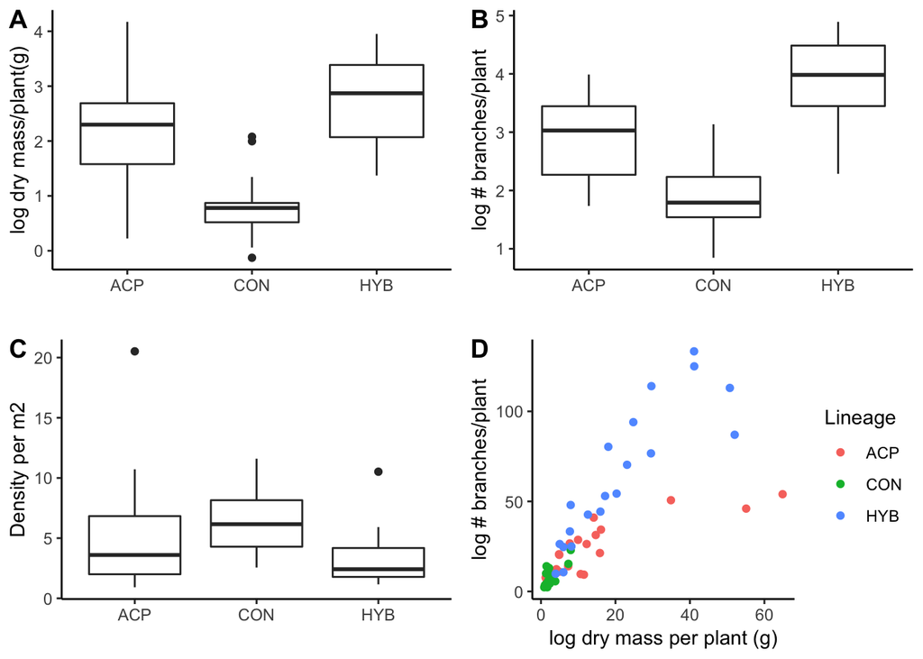

# Fitting a Linear Model to Describe the Data

To formally test these observations, I built a model to test whether the growth metrics vary by lineage. I fit a model to test how lineage affects growht, and I included environmental factors in the model, as well as the interaction between lineage and environmental factors. I included these interaction effects because we are interested in the effect of lineage on growth, but each lineage may grow differently under environmental factors. This interaction effect thus seems important to know for conservation purposes–for example, if hybrid plants grow larger in higher temperatures, then it may be wise to remove hybrids from hotter lakes, since they are more likely to grow faster and disrupt native life in this environment.

Because of the many factors that could contribute to growth, I first optimized a model to decide which factors contribute the most to the model. I do not want to include factors that do not significantly add to the model. To optimize the model, I used Aikaike’s information criterion (AIC), which compares the likelihoods of multiple versions of models to find the simplest model that is also the most explanatory. Based on this criterion, I chose the following models (one model to explain each growth metric):

Dry_Mass_per_Plant_g ~ Lineage + Dissolved_O2 + Temperature + Conductivity + Alkalinity + pH + Lineage:Temperature + Lineage:Alkalinity + Lineage:pH

Total_Branches_per_Plant ~ Lineage + Dissolved_O2 + Temperature + Conductivity + Alkalinity + Lineage:Dissolved_O2 + Lineage:Temperature + Lineage:Alkalinity

Density_per_m2 ~ Lineage + Conductivity + pH + Lineage:pH

# Examining the coefficients of the optimized model to answer the question: Does the hybrid grow more aggressively?

The results below show the coefficients from each model of growth metrics. I will discuss what the coefficients show about how lineage and other factors contribute to growth.

**What factors contribute to dry mass per plant?**

Despite the higher mean shown on the boxplots (A above), the HYB lineage actually has a smaller coefficient than ACP. Furthermore, these differences between lineage are not significant. The significant interaction effects show that the effect of temperature, alkalinity, and pH on growth depends on the lineage. I also tested whether the model with only additive effects would change the coefficients (below). In the additive model, the hybrid lineage has greater dry mass than ACP, but this is a small difference: ACP = 44, HYB = 48. In the additive model also the coefficients are not significant. I conclude that lineage does not influence dry mass per plant very much and that the hybrid lineage does not have greater dry mass than the other lineages.

```
##
## Call:
## lm(formula = Dry_Mass_per_Plant_g ~ 0 + Lineage + Dissolved_O2 +
##     Temperature + Conductivity + Alkalinity + pH + Lineage:Temperature +
##     Lineage:Alkalinity + Lineage:pH, data = invasiveData)
##
## Residuals:
##      Min       1Q   Median       3Q      Max
## -23.0073  -3.8881   0.1162   2.6500  19.3839
##
## Coefficients:
##                         Estimate Std. Error t value Pr(>|t|)
## LineageACP              72.33888   51.33089   1.409 0.165202
## LineageCON               6.18551   36.66696   0.169 0.866746
## LineageHYB              58.06639   41.92630   1.385 0.172467
## Dissolved_O2             0.27391    0.12118   2.260 0.028368 *
## Temperature              1.13258    0.86449   1.310 0.196390
## Conductivity            -0.17570    0.06053  -2.903 0.005575 **
## Alkalinity               1.94771    0.41993   4.638 2.73e-05 ***
## pH                     -18.83895    7.05767  -2.669 0.010340 *
## LineageCON:Temperature  -2.09065    1.55056  -1.348 0.183886
## LineageHYB:Temperature  -2.89840    1.09293  -2.652 0.010813 *
## LineageCON:Alkalinity   -1.53867    0.40559  -3.794 0.000416 ***
## LineageHYB:Alkalinity   -1.31226    0.37688  -3.482 0.001072 **
## LineageCON:pH           19.19299    8.70382   2.205 0.032269 *
## LineageHYB:pH           16.16678    9.00726   1.795 0.078974 .
## ---
## Signif. codes:  0 '***' 0.001 '**' 0.01 '*' 0.05 '.' 0.1 ' ' 1
##
## Residual standard error: 9.324 on 48 degrees of freedom
## Multiple R-squared:  0.8234, Adjusted R-squared:  0.7719
## F-statistic: 15.99 on 14 and 48 DF,  p-value: 1.649e-13
```

```
## [1] "Coefficients for dry mass - additive only"
```

```
##
## Call:
## lm(formula = Dry_Mass_per_Plant_g ~ 0 + Lineage + Dissolved_O2 +
##     Temperature + Conductivity + Alkalinity + pH, data = invasiveData)
##
## Residuals:
##     Min      1Q  Median      3Q     Max
## -18.758  -6.434  -1.296   5.323  39.258
##
## Coefficients:
##              Estimate Std. Error t value Pr(>|t|)
## LineageACP   44.47212   28.52131   1.559  0.12478
## LineageCON   35.01563   29.10070   1.203  0.23413
## LineageHYB   48.51860   28.86604   1.681  0.09857 .
## Dissolved_O2  0.19126    0.14221   1.345  0.18430
## Temperature  -0.80825    0.54313  -1.488  0.14253
## Conductivity -0.06348    0.06266  -1.013  0.31547
## Alkalinity    0.46533    0.15987   2.911  0.00523 **
## pH           -4.52867    4.22713  -1.071  0.28878
## ---
## Signif. codes:  0 '***' 0.001 '**' 0.01 '*' 0.05 '.' 0.1 ' ' 1
##
## Residual standard error: 11.38 on 54 degrees of freedom
## Multiple R-squared:  0.7041, Adjusted R-squared:  0.6602
## F-statistic: 16.06 on 8 and 54 DF,  p-value: 7.808e-12
```

**What factors contribute to the number of branches per plant?**

In contrast, the hybrid lineage does differ in number of branches per plant. This is a large and a significant difference. However, the hybrid plants’ number of branches and the temperature of lakes is negatively related, suggesting that hybrids grow better in cooler lakes. Conductivity and alkalinity also significantly determine to the number of branches per plant for all lineages.

```
##
## Call:
## lm(formula = Total_Branches_per_Plant ~ 0 + Lineage + Dissolved_O2 +
##     Temperature + Conductivity + Alkalinity + Lineage:Dissolved_O2 +
##     Lineage:Temperature + Lineage:Alkalinity, data = invasiveData)
##
## Residuals:
##     Min      1Q  Median      3Q     Max
## -40.748  -8.452  -0.669   5.988  54.552
##
## Coefficients:
##                         Estimate Std. Error t value Pr(>|t|)
## LineageACP               12.4153    53.8963   0.230  0.81878
## LineageCON               59.2406    76.0869   0.779  0.43996
## LineageHYB              133.1962    42.7941   3.112  0.00309 **
## Dissolved_O2             -0.4498     0.3745  -1.201  0.23549
## Temperature               1.4792     1.5956   0.927  0.35844
## Conductivity             -0.3192     0.1434  -2.227  0.03059 *
## Alkalinity                2.0650     0.8288   2.491  0.01616 *
## LineageCON:Dissolved_O2   0.7837     0.9015   0.869  0.38891
## LineageHYB:Dissolved_O2   1.0485     0.5184   2.023  0.04860 *
## LineageCON:Temperature   -4.0761     2.7803  -1.466  0.14902
## LineageHYB:Temperature   -6.6278     2.0352  -3.257  0.00205 **
## LineageCON:Alkalinity    -1.3802     0.7452  -1.852  0.07005 .
## LineageHYB:Alkalinity    -0.8336     0.7075  -1.178  0.24439
## ---
## Signif. codes:  0 '***' 0.001 '**' 0.01 '*' 0.05 '.' 0.1 ' ' 1
##
## Residual standard error: 17.66 on 49 degrees of freedom
## Multiple R-squared:  0.8782, Adjusted R-squared:  0.8459
## F-statistic: 27.19 on 13 and 49 DF,  p-value: < 2.2e-16
```

**What factors contribute to the density of plants?**

The CON lineage does have higher density than the other lineages, but these differences are not significant. Additionally, pH contributes significantly to the density of plants.

```
##
## Call:
## lm(formula = Density_per_m2 ~ 0 + Lineage + Conductivity + pH +
##     Lineage:pH, data = NAinvasiveData)
##
## Residuals:
##     Min      1Q  Median      3Q     Max
## -5.0345 -1.9866 -0.2788  1.4679 12.5633
##
## Coefficients:
##                Estimate Std. Error t value Pr(>|t|)
## LineageACP    -31.24217   15.70505  -1.989   0.0525 .
## LineageCON     10.06736   13.03433   0.772   0.4438
## LineageHYB      8.81060   14.66753   0.601   0.5509
## Conductivity   -0.01859    0.01199  -1.551   0.1275
## pH              5.07820    2.07360   2.449   0.0181 *
## LineageCON:pH  -5.36045    2.69040  -1.992   0.0521 .
## LineageHYB:pH  -5.56938    2.87432  -1.938   0.0587 .
## ---
## Signif. codes:  0 '***' 0.001 '**' 0.01 '*' 0.05 '.' 0.1 ' ' 1
##
## Residual standard error: 3.309 on 47 degrees of freedom
## Multiple R-squared:  0.7464, Adjusted R-squared:  0.7086
## F-statistic: 19.76 on 7 and 47 DF,  p-value: 4.766e-12
```

# Comparing models with the random effect of lake and without the random effect of lake

So far, I have been comparing plants that come from many different lakes across New England. Therefore, these samples are not completely comparable, because the effect of the lake may influence growth metrics. In order to account for the effect of lake, I introduced lake as a random factor to my optimized models. I chose to include lake as a random factor rather than a standard factor because although different lakes may influence growth factors, I do not care about the effect of lake and so do not want to explicitly test the effect of each lake. Another practical reason to not include lake as a standard factor is that doing so will greatly increase the degrees of freedom involved and thus decrease statistical power.

```
##
## Call:
## lm(formula = Dry_Mass_per_Plant_g ~ 0 + Lineage + Dissolved_O2 +
##     Temperature + Conductivity + Alkalinity + pH + Lineage:Temperature +
##     Lineage:Alkalinity + Lineage:pH, data = invasiveData)
##
## Coefficients:
##             LineageACP              LineageCON              LineageHYB
##                72.3389                  6.1855                 58.0664
##           Dissolved_O2             Temperature            Conductivity
##                 0.2739                  1.1326                 -0.1757
##             Alkalinity                      pH  LineageCON:Temperature
##                 1.9477                -18.8389                 -2.0906
## LineageHYB:Temperature   LineageCON:Alkalinity   LineageHYB:Alkalinity
##                -2.8984                 -1.5387                 -1.3123
##          LineageCON:pH           LineageHYB:pH
##                19.1930                 16.1668
```

```
## Linear mixed model fit by REML ['lmerMod']
## Formula: Dry_Mass_per_Plant_g ~ 0 + Lineage + (1 | Lake) + Dissolved_O2 +
##     Temperature + Conductivity + Alkalinity + pH + Lineage:Temperature +
##     Lineage:Alkalinity + Lineage:pH
##    Data: invasiveData
## REML criterion at convergence: 420.923
## Random effects:
##  Groups   Name        Std.Dev.
##  Lake     (Intercept) 2.621
##  Residual             9.125
## Number of obs: 62, groups:  Lake, 20
## Fixed Effects:
##             LineageACP              LineageCON              LineageHYB
##                67.9169                  6.4641                 58.5986
##           Dissolved_O2             Temperature            Conductivity
##                 0.2740                  1.0515                 -0.1737
##             Alkalinity                      pH  LineageCON:Temperature
##                 1.9783                -18.1259                 -1.9998
## LineageHYB:Temperature   LineageCON:Alkalinity   LineageHYB:Alkalinity
##                -2.7732                 -1.5752                 -1.3476
##          LineageCON:pH           LineageHYB:pH
##                18.3999                 15.2221
```

# Formal model comparison test

The random effect of lake is not a significant source of variation. Perhaps lake environments are similar or do not contribute to growth in meaningful ways, or perhaps the other environmental factors measured (temperature, o2 content, alkalinity, conductivity, and pH), which are specific to lakes, better account for the variation than the random effect of lakes.

In conclusion, the hybrid lineage does not differ from the other lineages in mass or density. the hybrid lineage does grow more branches. Growing more branches may have misled people to think the hybrid lineage grows more aggressively–the plants from the hybrid lineage may *look* bigger, but in fact they do not differ in mass and density. thus, removal of the hybrids should not be more difficult than removel of the ACP lineage. However, biologists studying this plant should consider whether growing more branches is perhaps more detrimental to native wildlife. Perhaps even though these plants are not bigger in mass, perhaps more branches take up more space and block out more sun for other aquatic life. Biologists should also note that pH, temperature, and oxygen content contribute to growth metrics. These results should help conservationists prioritize which lakes to target removal of this invasive species.